# TCR and CO2 concentration in AR6 and CMIP6

Doug McNeall

2023-01-06

We fit distributions to assessed quantiles of TCR in the literature, and then push those through the transfer function from Betts & McNeall (2018) to find an implied CO2 concentrayion at warming levels 1.5 and 2 degrees above preindustrial.

# Quantiles from the literature

There are a number of sources of assessed probability distributions for TCR (sometimes just quantiles) in the literature. A complicating factor is that they often give a small number of different quantiles, or probability ranges, leaving a large number of potential distributions that would fit. For example, they might state a 66% probability range, without specifying the quantiles this range aplies to.

### AR5 (assessed range)

“likley” range (66% probability)

1 - 2.5 deg C

Also “positive” and “extremely unlikely” (5% probability) above 3"

I interpret this as

| quantile | 0% | 17% | 83% | 97.5% |
| --- | --- | --- | --- | --- |
| tcr | 0 | 1 | 2.5 | 3 |

But it’s possible to interpret that upper quantile as 95%, as there is ambiguity around whether the 5% probability should be split over both tails of the distribution. . I’ll update this possible inconsistancy as I find out.

### CMIP5 models

AR5 Box 12.2 states:

“5 to 95% range of CMIP5 (1.2°C to 2.4°C; see Table 9.5), is positive and extremely unlikely greater than 3°C.” As this explicitly mentions the 95% *and* the “extremely unlikely” statement, that lends evidence that “extremely unlikely” is spread over both tails, and refers to the 97.5th percentile.

[output not shown]

### Schurer eta al (2018)

Multimodel mean with increased variance for model uncertainty

| quantile | 5% | 50% | 95% |
| --- | --- | --- | --- |
| tcr | 1.2 | 1.7 | 2.4 |

### Sherwood et al (2020)

Likely (66% probability) range

| quantile | 16% | 50% | 84% |
| --- | --- | --- | --- |
| tcr | 1.5 | 1.8 | 2.2 |

### Jiménez-de-la Cuesta and Mauritsen (2019)

| quantile | 5% | 50% | 95% |
| --- | --- | --- | --- |
| tcr | 1.17 | 1.7 | 2.16 |

### Tokarska et al (2020)

| quantile | 16% | 50% | 84% |
| --- | --- | --- | --- |
| tcr | 1.2 | 1.6 | 2.0 |

### Njisse et al. (2020)

Njisse et al. (2020) CMIP5 models

| quantile | 5% | 16% | 50% | 84% | 95% |
| --- | --- | --- | --- | --- | --- |
| tcr | 1.1 | 1.4 | 1.7 | 2.1 | 2.4 |

Njisse et al. (2020) CMIP6 models

| quantile | 5% | 16% | 50% | 84% | 95% |
| --- | --- | --- | --- | --- | --- |
| tcr | 1 | 1.29 | 1.68 | 2.05 | 2.3 |

## Distributions used in Betts & McNeall (2018)

```r
dx = 100
tcr_range = seq(from = 0, to = 5, by = 1/dx)
```

```r
# Very approximately, the TCR distribution is N(1.75, 0.5)
# MC sample, and plug that into the transfer function
# Still to do: pick a closer mean/sd (perhaps non normal?)
tcrmean = 1.75
tcrsd_used = 0.45 # incorrectly used in the paper.
tcrsd = 0.75 # The final result is very sensitive to lower tail of tcr distribution

qnorm(p = c(0.16, 0.84), mean = tcrmean, sd = tcrsd_used)
```

```
[1] 1.302494 2.197506
```

```r
qnorm(p = c(0.16, 0.84), mean = tcrmean, sd = tcrsd)
```

```
[1] 1.004157 2.495843
```

```r
# A plot of what the assumed tcr distribution looks like
tcrdens_used = dnorm(tcr_range, mean = tcrmean, sd = tcrsd_used)
#tcrsamp_used  = rnorm(10000, mean = tcrmean, sd = tcrsd_used)

tcrdens = dnorm(tcr_range, mean = tcrmean, sd = tcrsd)
```

```r
#par(las = 1)
#plot(tcr_range, tcrdens_used, type = 'l', lwd = 2, main = "pr(TCR)", xlab = "TCR", ylab = "Probability density" )
#lines(tcr_range, tcrdens, col = 'red', lwd = 2 )
#legend('topright', c('used in paper', 'corrected Normal distribution'), lty = 'solid', col = c('black', 'red'))
```

## Other distributions to might fit TCR better

The distribution from Richardson is asymmetric, and there is evidence that the other distributions representing scientists beliefs are asymmetric too. Normal distributions can easily place significant probability below zero, which is explicitly ruled out in the AR5 assessment.

Other distributions, such as Gamma or lognormal, might fit better.

For example, here is a Gamma distribution with some sensible-looking parameters.

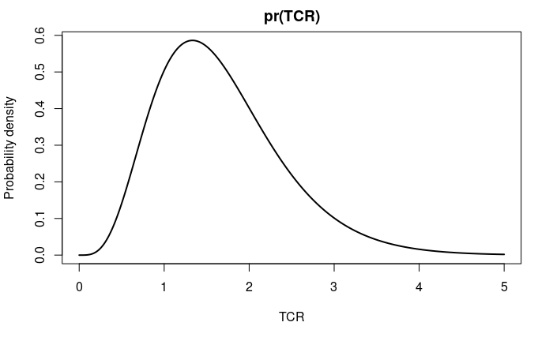

```r
gdens <- dgamma(x = tcr_range, shape = 5, rate = 3)

plot(tcr_range, gdens, type = 'l', lwd = 2, main = "pr(TCR)", xlab = "TCR", ylab = "Probability density" )
```

## Fit distributions to the Richardson samples from their TCR distribution

```r
# Load Richardson TCR samples from distribution
atcrpdf = as.numeric(readLines("../richardson/atcrpdf.txt"))
atcrpdf.trunc = atcrpdf[atcrpdf<12 & atcrpdf >0]
```

```r
#library(fitdistrplus)
```

Fit the Gamma distribution, starting from the above parameters.

```r
#start.gamma <- list(shape = 5, rate = 3)
#fit.gamma <- fitdist(atcrpdf.trunc, distr = "gamma", method = "mle", start = start.gamma)
#summary(fit.gamma)
```

```r
#plot(fit.gamma)
```

### Fit a lognormal distribution to Richardson

```r
# lognormal?
# A lognormal distribution seems to fit the

#fit.lnorm <- fitdist(atcrpdf.trunc, distr = "lnorm", method = "mle")
#summary(fit.lnorm)

#plot(fit.lnorm)

#exp(fit.lnorm$estimate)
```

## Fit a lognormal distribution to all of the distributions from the literature

```
The fitting procedure 'L-BFGS-B' was successful!
```

```
$par
[1] 0.4370346 0.4324224

$value
[1] 0.0002381779

$counts
function gradient
      13       13

$convergence
[1] 0

$message
[1] "CONVERGENCE: REL_REDUCTION_OF_F <= FACTR*EPSMCH"
```

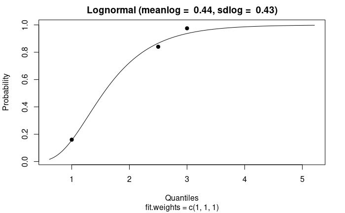

```r
library(rriskDistributions)

# Quantiles and probabilities from the various estimates

# AR5 assessed likely
p_ar5 <- c(0.16, 0.84, 0.975)
q_ar5 <- c(1, 2.5, 3)

# CMIP5 models
p_cmip5 <- c(0.05, 0.95, 0.975)
q_cmip5 <- c(1.2, 2.5, 3)

p_schurer <- c(0.05,0.50, 0.95)
q_schurer <- c(1.2, 1.7, 2.4)

p_sherwood <- c(0.16,0.50, 0.84)
q_sherwood <- c(1.5, 1.8, 2.2)

p_richardson <- c(0.05, 0.50, 0.95)
q_richardson <- quantile(atcrpdf.trunc, p_richardson) # check these

p_njisse_cmip5 <- c(0.05, 0.16, 0.5, 0.84, 0.95)
q_njisse_cmip5 <- c(1.1, 1.4, 1.7, 2.1, 2.4 )

p_njisse_cmip6 <- c(0.05, 0.16, 0.5, 0.84, 0.95)
q_njisse_cmip6 <- c(1, 1.29, 1.68, 2.05, 2.3)
# Calculate the parameters of a lognormal distribution that would fit those parameters


p_jimenez <- c(0.05, 0.5, 0.95)
q_jimenez <- c(1.17, 1.7, 2.16)

p_tokarska <- c(0.16, 0.5, 0.84)
q_tokarska <- c(1.2, 1.6, 2.0)


lnpar_ar5 <- get.lnorm.par(p = p_ar5, q_ar5)
```

```
The fitting procedure 'L-BFGS-B' was successful!
```

```
$par
[1] 0.5528290 0.2264219

$value
[1] 3.430531e-05

$counts
function gradient
       9        9

$convergence
[1] 0

$message
[1] "CONVERGENCE: REL_REDUCTION_OF_F <= FACTR*EPSMCH"
```

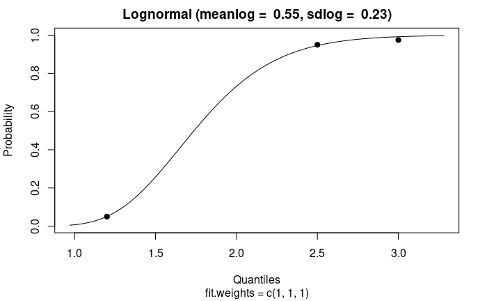

```r
lnpar_cmip5 <- get.lnorm.par(p=p_cmip5 , q=q_cmip5)
```

```
The fitting procedure 'L-BFGS-B' was successful!
```

```
$par
[1] 0.5304240 0.2106881

$value
[1] 1.41057e-07

$counts
function gradient
      12       12

$convergence
[1] 0

$message
[1] "CONVERGENCE: REL_REDUCTION_OF_F <= FACTR*EPSMCH"
```

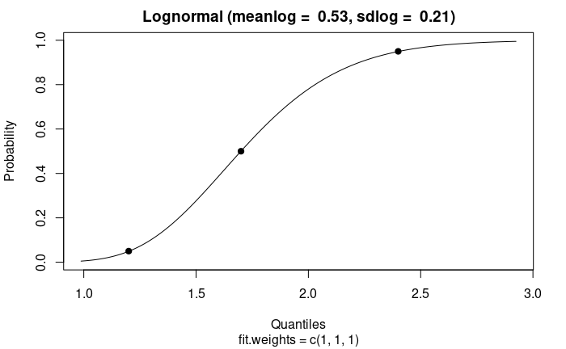

```r
# Schurer paper
lnpar_schurer <- get.lnorm.par(p=p_schurer, q=q_schurer)
```

```
The fitting procedure 'L-BFGS-B' was successful!
```

```
$par
[1] 0.5917034 0.1926020

$value
[1] 1.712434e-05

$counts
function gradient
      20       20

$convergence
[1] 0

$message
[1] "CONVERGENCE: REL_REDUCTION_OF_F <= FACTR*EPSMCH"
```

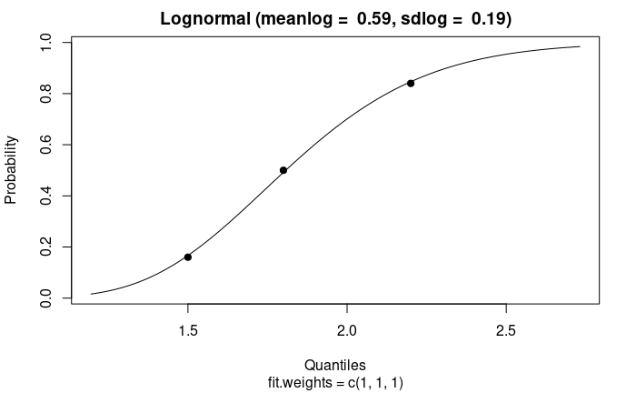

```r
# Sherwood paper
lnpar_sherwood <- get.lnorm.par(p=p_sherwood, q=q_sherwood)
```

```
The fitting procedure 'L-BFGS-B' was successful!
```

```
$par
[1] 0.5171894 0.3200099

$value
[1] 0.0001466232

$counts
function gradient
      12       12

$convergence
[1] 0

$message
[1] "CONVERGENCE: REL_REDUCTION_OF_F <= FACTR*EPSMCH"
```

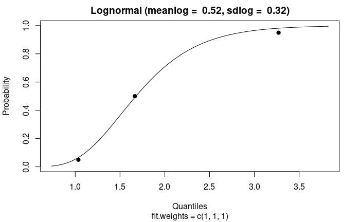

```r
#richardson paper
# This is different from the fit.lnorm
lnpar_richardson <- get.lnorm.par(p=p_richardson, q=q_richardson)
```

```
The fitting procedure 'L-BFGS-B' was successful!
```

```
$par
[1] 0.5333458 0.2088702

$value
[1] 4.883697e-05

$counts
function gradient
      13       13

$convergence
[1] 0

$message
[1] "CONVERGENCE: REL_REDUCTION_OF_F <= FACTR*EPSMCH"
```

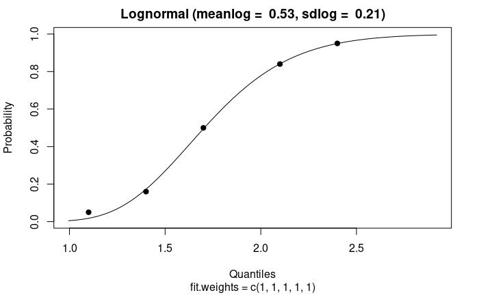

```r
lnpar_njisse_cmip5 <- get.lnorm.par(p=p_njisse_cmip5, q = q_njisse_cmip5)
```

```
The fitting procedure 'L-BFGS-B' was successful!
```

```
$par
[1] 0.5011289 0.2300069

$value
[1] 0.0001314229

$counts
function gradient
      13       13

$convergence
[1] 0

$message
[1] "CONVERGENCE: REL_REDUCTION_OF_F <= FACTR*EPSMCH"
```

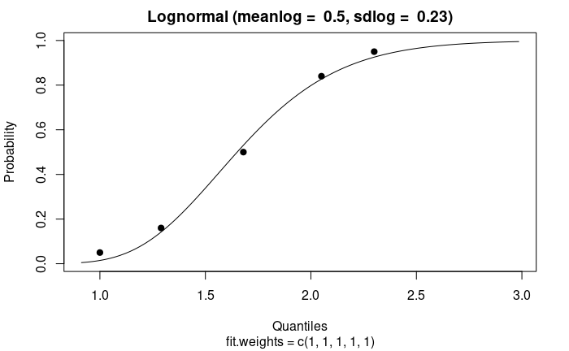

```r
lnpar_njisse_cmip6 <- get.lnorm.par(p=p_njisse_cmip6, q = q_njisse_cmip6)
```

```
The fitting procedure 'L-BFGS-B' was successful!
```

```
$par
[1] 0.5279935 0.1582696

$value
[1] 0.0002056946

$counts
function gradient
      13       13

$convergence
[1] 0

$message
[1] "CONVERGENCE: REL_REDUCTION_OF_F <= FACTR*EPSMCH"
```

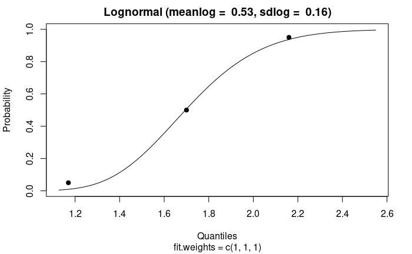

```r
lnpar_jimenez <- get.lnorm.par(p=p_jimenez, q = q_jimenez)
```

```
The fitting procedure 'L-BFGS-B' was successful!
```

```
$par
[1] 0.4561703 0.2572126

$value
[1] 0.0001190927

$counts
function gradient
      13       13

$convergence
[1] 0

$message
[1] "CONVERGENCE: REL_REDUCTION_OF_F <= FACTR*EPSMCH"
```

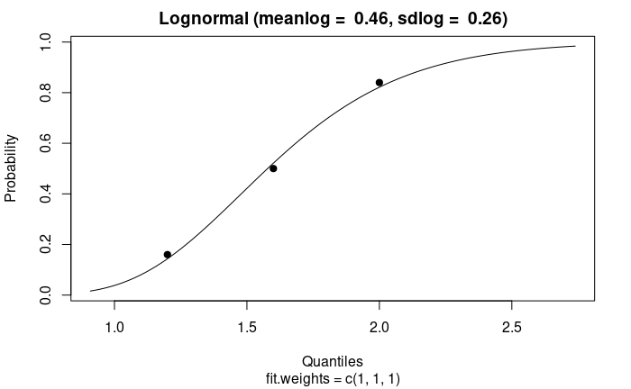

```r
lnpar_tokarska<- get.lnorm.par(p=p_tokarska, q = q_tokarska)
```

## Plot all of the lognormal fits

```r
ar5_ln_dens <- dlnorm(x = tcr_range, meanlog = lnpar_ar5['meanlog'], sdlog = lnpar_ar5['sdlog'] )
cmip5_ln_dens <- dlnorm(x = tcr_range, meanlog = lnpar_cmip5['meanlog'], sdlog = lnpar_cmip5['sdlog'] )
schurer_ln_dens <- dlnorm(x = tcr_range, meanlog = lnpar_schurer['meanlog'], sdlog = lnpar_schurer['sdlog'] )
sherwood_ln_dens <- dlnorm(x = tcr_range, meanlog = lnpar_sherwood['meanlog'], sdlog = lnpar_sherwood['sdlog'] )
richardson_ln_dens <- dlnorm(x = tcr_range, meanlog = lnpar_richardson['meanlog'], sdlog = lnpar_richardson['sdlog'])
njisse_cmip5_ln_dens <- dlnorm(x = tcr_range, meanlog = lnpar_njisse_cmip5['meanlog'], sdlog = lnpar_njisse_cmip5['sdlog'])
njisse_cmip6_ln_dens <- dlnorm(x = tcr_range, meanlog = lnpar_njisse_cmip6['meanlog'], sdlog = lnpar_njisse_cmip6['sdlog'])
jimenez_ln_dens <- dlnorm(x = tcr_range, meanlog = lnpar_jimenez['meanlog'], sdlog = lnpar_jimenez['sdlog'])
tokarska_ln_dens <- dlnorm(x = tcr_range, meanlog = lnpar_tokarska['meanlog'], sdlog = lnpar_tokarska['sdlog'])

h <- hist(atcrpdf.trunc, breaks = 30, plot = FALSE)

yfit_richardson <- richardson_ln_dens*diff(h$mids[1:2])*length(atcrpdf.trunc)
yfit_schurer <- schurer_ln_dens*diff(h$mids[1:2])*length(atcrpdf.trunc)
yfit_sherwood <- sherwood_ln_dens*diff(h$mids[1:2])*length(atcrpdf.trunc)
yfit_cmip5 <- cmip5_ln_dens*diff(h$mids[1:2])*length(atcrpdf.trunc)
yfit_ar5 <- ar5_ln_dens*diff(h$mids[1:2])*length(atcrpdf.trunc)
yfit_njisse_cmip5 <- njisse_cmip5_ln_dens*diff(h$mids[1:2])*length(atcrpdf.trunc)
yfit_njisse_cmip6 <- njisse_cmip6_ln_dens*diff(h$mids[1:2])*length(atcrpdf.trunc)
yfit_jimenez <- jimenez_ln_dens*diff(h$mids[1:2])*length(atcrpdf.trunc)
yfit_tokarska <- tokarska_ln_dens*diff(h$mids[1:2])*length(atcrpdf.trunc)

rn <- range(yfit_richardson, yfit_schurer,yfit_sherwood,yfit_cmip5, yfit_ar5,yfit_njisse_cmip5, yfit_njisse_cmip6,yfit_jimenez,yfit_tokarska)

plot(h, xlim = c(0,4), ylim = rn, xlab = 'TCR', ylab = 'density', main = 'lognormal fits to quantiles')
lines(tcr_range, yfit_richardson, lwd = 3, col = 'orange')
```

```r
lines(tcr_range, yfit_schurer, lwd = 3, col = 'red')
lines(tcr_range, yfit_sherwood, lwd = 3, col = 'blue')
```

```r
lines(tcr_range, yfit_cmip5, lwd = 3, col = 'black')
lines(tcr_range, yfit_ar5, lwd = 3, col = 'pink')
```

```r
lines(tcr_range, yfit_njisse_cmip5, lwd = 3, col = 'purple', lty = 'dashed')
lines(tcr_range, yfit_njisse_cmip6, lwd = 3, col = 'purple')
```

```r
lines(tcr_range, yfit_jimenez, lwd = 3, col = 'darkgrey')
lines(tcr_range, yfit_tokarska, lwd = 3, col = 'darkblue')
```

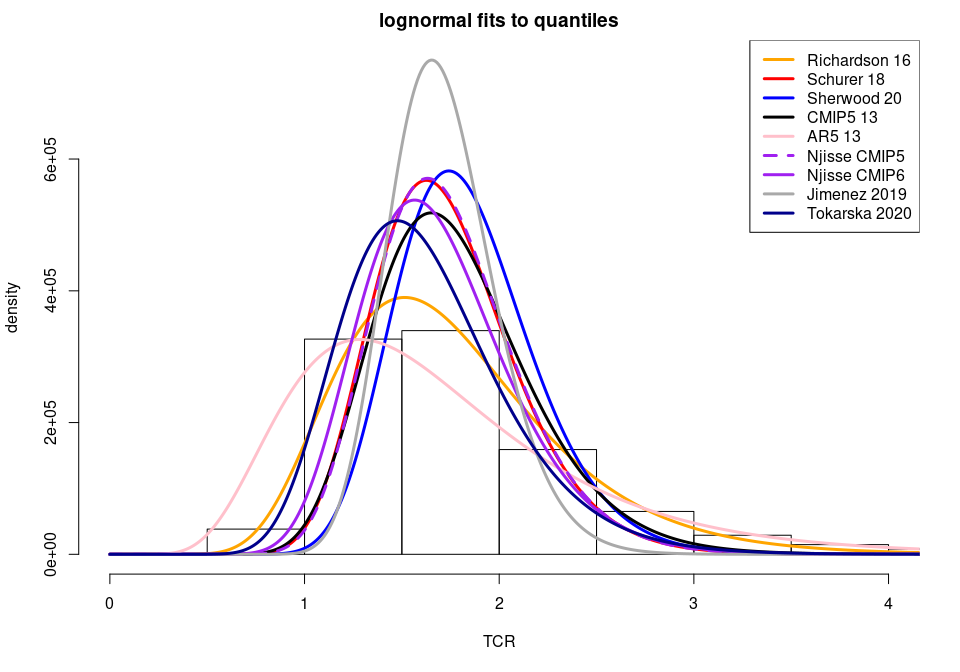

```r
legend('topright', c('Richardson 16', 'Schurer 18', 'Sherwood 20', 'CMIP5 13', 'AR5 13', 'Njisse CMIP5', 'Njisse CMIP6', 'Jimenez 2019', 'Tokarska 2020'),
       col = c('orange', 'red', 'blue', 'black','pink', 'purple', 'purple', 'darkgrey', 'darkblue'), lwd = 3, lty = c('solid','solid','solid','solid','solid','dashed','solid', 'solid', 'solid'))
```

```r
NA
NA
```

## How close are the lognormal fits?

```r
# Plot theoretical vs actual quantile for each fit
par(las = 1)
plot(q_ar5, qlnorm(p=p_ar5, meanlog = lnpar_ar5['meanlog'],  sdlog =  lnpar_ar5['sdlog']),
     col = 'pink', pch = 19,
     xlim = c(0.5,4.5), ylim = c(0.5,4.5),
     xlab = 'given quantile', ylab = 'fitted quantile')
points(q_cmip5, qlnorm(p=p_cmip5, meanlog = lnpar_cmip5['meanlog'],  sdlog =  lnpar_cmip5['sdlog']),
       col = 'black', pch = 19)
```

```r
points(q_sherwood, qlnorm(p=p_sherwood, meanlog = lnpar_sherwood['meanlog'],  sdlog =  lnpar_sherwood['sdlog']),
       col = 'blue', pch = 19)
points(q_schurer, qlnorm(p=p_schurer, meanlog = lnpar_schurer['meanlog'],  sdlog =  lnpar_schurer['sdlog']),
       col = 'red', pch = 19)
```

```r
points(q_richardson, qlnorm(p=p_richardson, meanlog = lnpar_richardson['meanlog'],  sdlog =  lnpar_richardson['sdlog']),
       col ='orange', pch = 19)


points(q_njisse_cmip5, qlnorm(p=p_njisse_cmip5, meanlog = lnpar_njisse_cmip5['meanlog'],  sdlog =  lnpar_njisse_cmip5['sdlog']),
       col ='purple', pch = 19)
```

```r
points(q_njisse_cmip6, qlnorm(p=p_njisse_cmip6, meanlog = lnpar_njisse_cmip6['meanlog'],  sdlog =  lnpar_njisse_cmip6['sdlog']),
       col ='purple', pch = 21)

points(q_jimenez, qlnorm(p=p_jimenez, meanlog = lnpar_jimenez['meanlog'],  sdlog =  lnpar_jimenez['sdlog']),
       col ='darkgrey', pch = 19)
```

```r
points(q_tokarska, qlnorm(p=p_tokarska, meanlog = lnpar_tokarska['meanlog'],  sdlog =  lnpar_tokarska['sdlog']),
       col ='darkblue', pch = 19)


legend('topleft', c('Richardson 16', 'Schurer 18', 'Sherwood 20', 'CMIP5 13', 'AR5 13', 'Njisse CMIP5', 'Njisse CMIP6',
                    'Jimenez 19', 'Tokarska 20'),
       col = c('orange', 'red', 'blue', 'black','pink', 'purple', 'purple', 'darkgrey', 'darkblue'),
       pch = c(19,19,19,19,19,19,21,19,19))
```

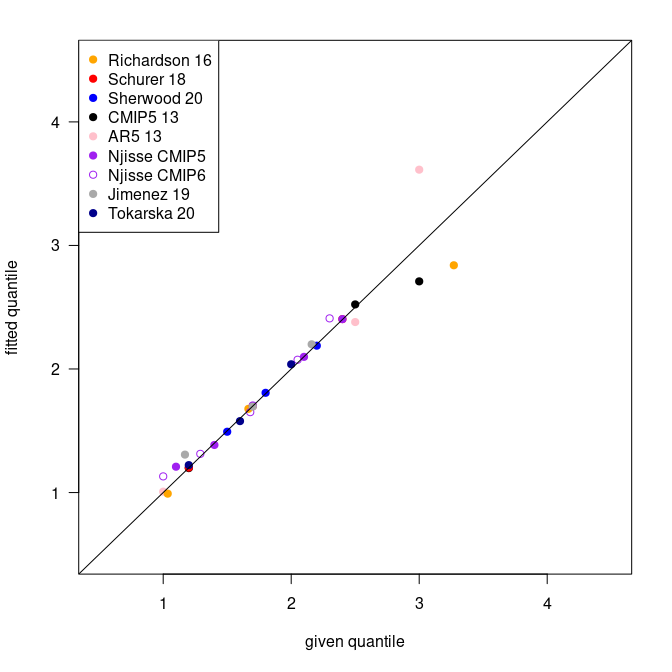

```r
abline(0,1)
```

```r
h <- hist(atcrpdf.trunc, prob = TRUE, ylim = c(0,1), xlim = c(0,4), main = 'Fit to richardson distribution')
d <- density(atcrpdf.trunc)

lines(d, lwd = 2)
```

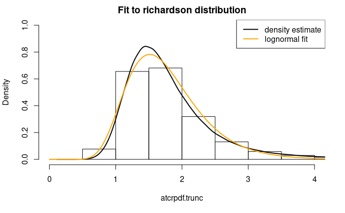

```r
lines(tcr_range,richardson_ln_dens, col = 'orange', lwd = 2)
legend('topright', legend = c('density estimate', 'lognormal fit'), col = c('black', 'orange'), lwd = 2)
```

```r
NA
NA
```

```r
# Set up a list of all the studies with distributions
namelist <- c('ar5_13', 'cmip5_13', 'richardson_16', 'schurer_18', 'jimenez_19', 'njisse_20_cmip5', 'njisse_20_cmip6', 'sherwood_20', 'tokarska_20', 'ar6_21_assessed')


ar5_13_quantiles <- list(p = c(0.17, 0.83, 0.975), q = c(1, 2.5, 3))

cmip5_13_quantiles <- list(p = c(0.05, 0.95, 0.975), q = c(1.2, 2.5, 3) )

richardson_16_quantiles <- list(p = c(0.05, 0.50, 0.95), q = quantile(atcrpdf.trunc, c(0.05, 0.50, 0.95)))

schurer_18_quantiles <- list(p = c(0.05,0.50, 0.95), q = c(1.2, 1.7, 2.4))

jimenez_19_quantiles <- list(p = c(0.05, 0.5, 0.95), q = c(1.17, 1.7, 2.16))

njisse_20_cmip5_quantiles <- list(p = c(0.05, 0.17, 0.5, 0.83, 0.95), q = c(1.1, 1.4, 1.7, 2.1, 2.4 ))

njisse_20_cmip6_quantiles <- list(p = c(0.05, 0.17, 0.5, 0.83, 0.95), q = c(1, 1.29, 1.68, 2.05, 2.3))

sherwood_20_quantiles <- list(p = c(0.17,0.50, 0.83), q = c(1.5, 1.8, 2.2))

tokarska_20_quantiles <- list(p =  c(0.17, 0.5, 0.83), q = c(1.2, 1.6, 2.0))

ar6_21_assessed_quantiles <- list(p = c(0.05, 0.17, 0.5, 0.83, 0.95) , q = c(1.2, 1.4, 1.8, 2.2, 2.4))


# Based on process understanding, warming over the instrumental
# record, and emergent constraints, the best estimate of TCR is
# 1.8°C, the likely range is 1.4°C to 2.2°C and the very likely
# range is 1.2°C to 2.4°C (high confidence). {7.5.5}
```

```
The fitting procedure 'L-BFGS-B' was successful!
```

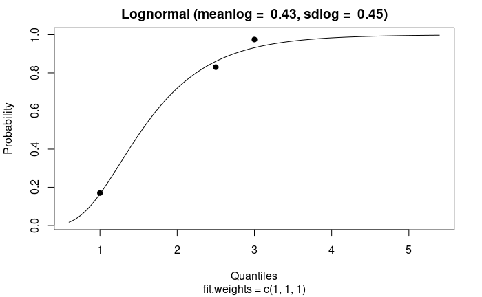

```
The fitting procedure 'L-BFGS-B' was successful!
```

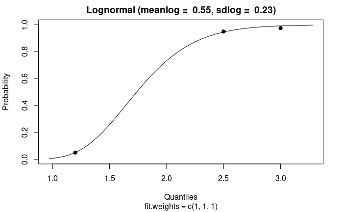

```
The fitting procedure 'L-BFGS-B' was successful!
```

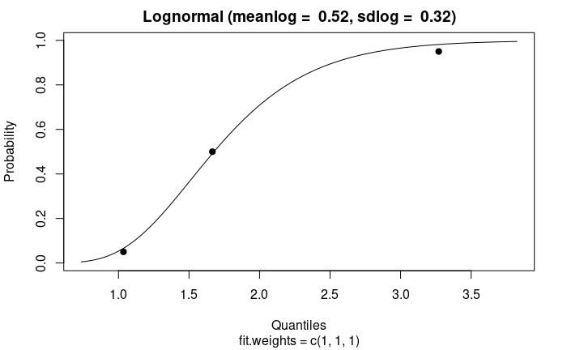

```
The fitting procedure 'L-BFGS-B' was successful!
```

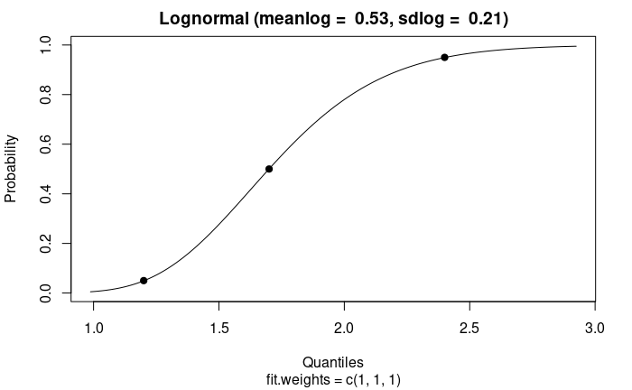

```
The fitting procedure 'L-BFGS-B' was successful!
```

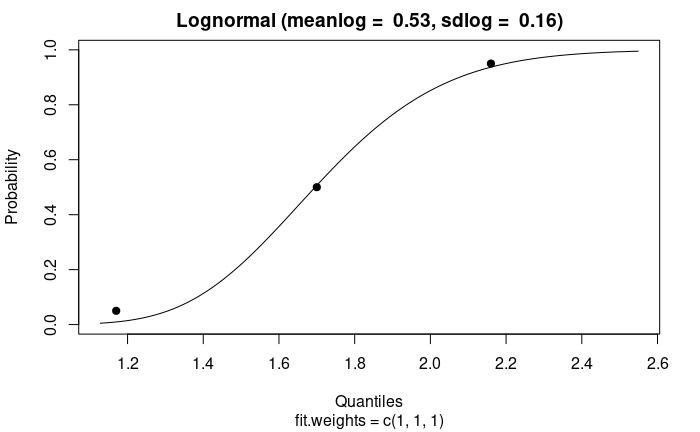

```
The fitting procedure 'L-BFGS-B' was successful!
```

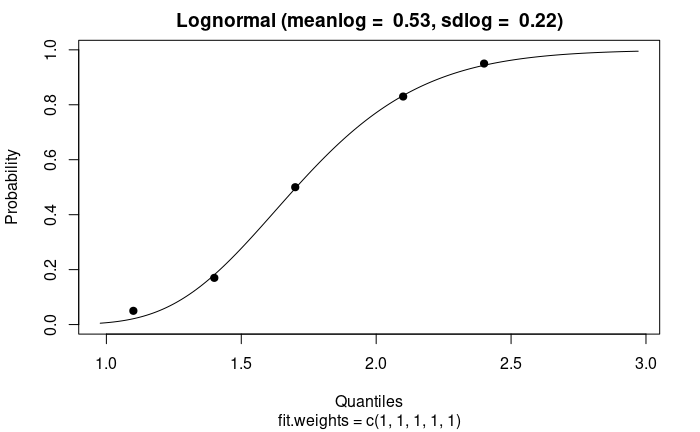

```
The fitting procedure 'L-BFGS-B' was successful!
```

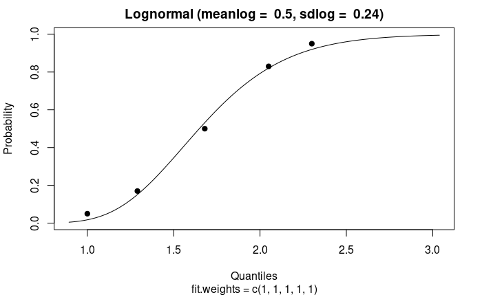

```
The fitting procedure 'L-BFGS-B' was successful!
```

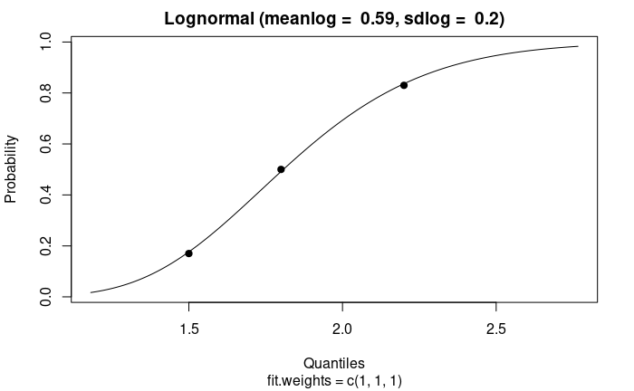

```
The fitting procedure 'L-BFGS-B' was successful!
```

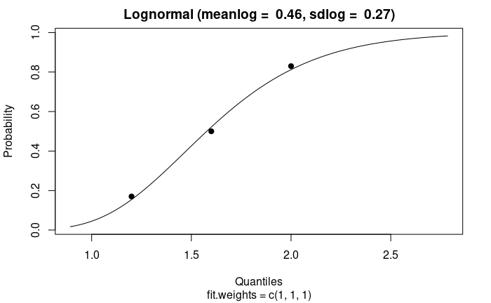

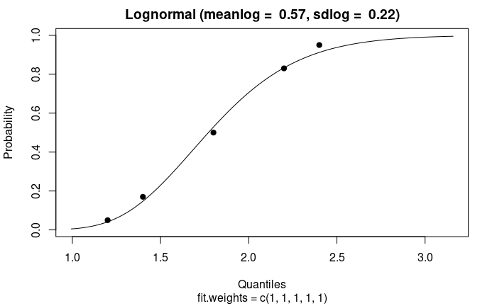

```r
# find the parameters and density of a lognormal distribution for each of the

for(i in namelist){

  pq <- get(paste0(i,'_quantiles'))
  lnpar <- get.lnorm.par(p = pq$p, pq$q, show.output = FALSE)
  assign(paste0(i,'_lnpar'), lnpar)
  dens <- dlnorm(x = tcr_range, meanlog = lnpar['meanlog'], sdlog = lnpar['sdlog'] )
  assign(paste0(i,'_lndens'), dens)
}
```